# Fitting Linear Models with Maximum Likelihood

*Inspired by “Fitting a Model by Maximum Likelihood”* *by Andrew of Exegetic Analytics*

https://www.r-bloggers.com/fitting-a-model-by-maximum-likelihood/

# ——————————————————————————–

### Understanding linear models

Linear models can be determined using the lm() function from base R. This is achieved using QR decomposition, an efficient method that avoids gradient descent. This is sufficient for most purposes, but uses a form of least squares to determine the best fit.

Using maximum likelihood requires gradient descent, but to implement it we must learn how linear models are made. First lets consider the following dataset, with the following spline regression.

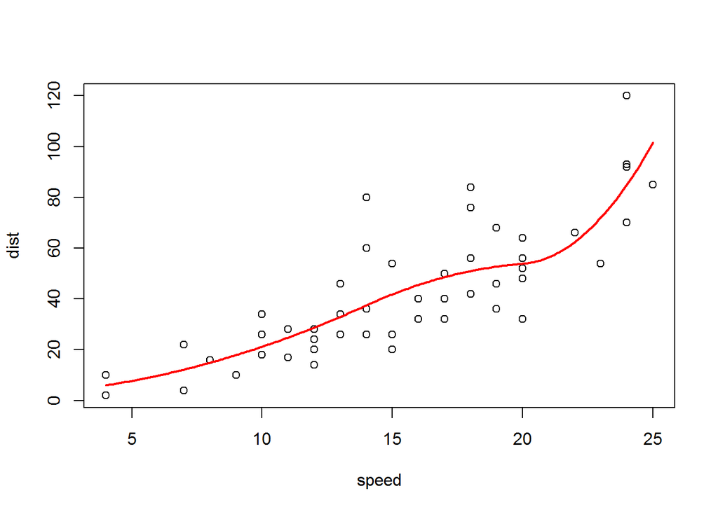

```r
  library(splines)
  K <- c(14, 20)  # knots
  plot(cars)
  lm.mod <- lm(dist ~ bs(speed, knots = c(K), degree = 2), data = cars)
  u <- seq(4, 25, by = 0.1)  # test model at these speeds
  B <- data.frame(speed = u)  # data.frame(speeds)
  lm.Y <- predict(lm.mod, newdata = B)  # predicted dist for the desired speeds
  lines(u, lm.Y, lwd = 2, col = "red")
```

Our aim is to fit a model using gradient descent so that maximum likelihood can be utilised.

So lets start with a basic example that doesn’t use splines:

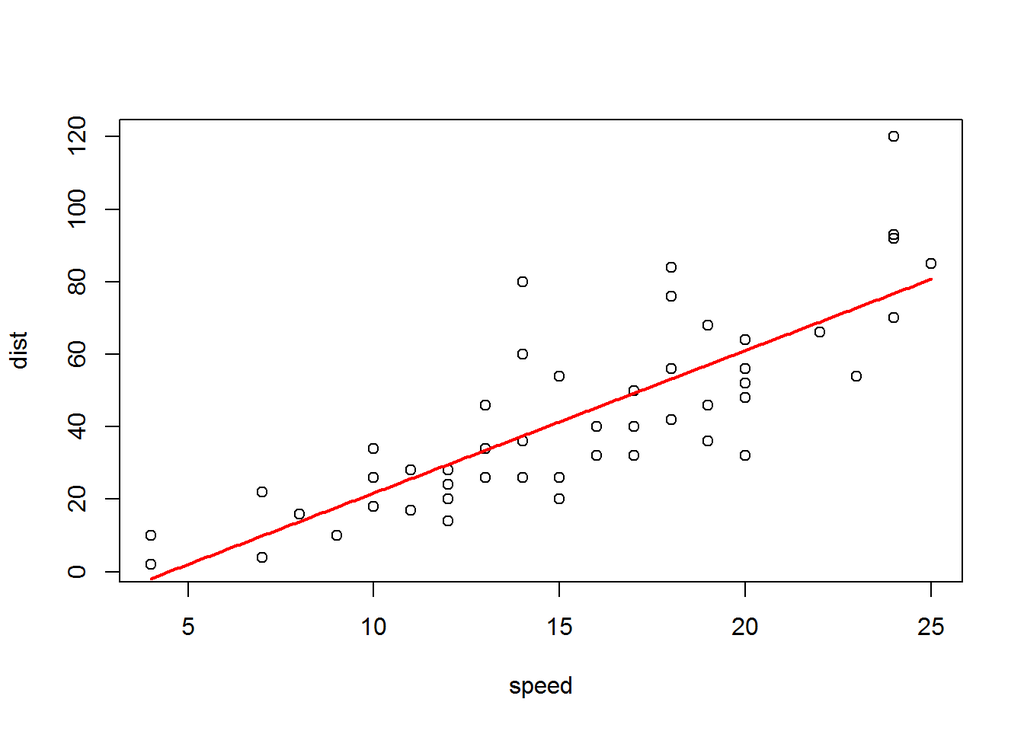

```r
  test.mod <- lm(dist ~ speed, data = cars)
  test.Y <- predict(test.mod, newdata = B)
  plot(cars)
  lines(u, test.Y, lwd = 2, col = "red")
```

```r
  summary(test.mod)
```

```
##
## Call:
## lm(formula = dist ~ speed, data = cars)
##
## Residuals:
##     Min      1Q  Median      3Q     Max
## -29.069  -9.525  -2.272   9.215  43.201
##
## Coefficients:
##             Estimate Std. Error t value Pr(>|t|)
## (Intercept) -17.5791     6.7584  -2.601   0.0123 *
## speed         3.9324     0.4155   9.464 1.49e-12 ***
## ---
## Signif. codes:  0 '***' 0.001 '**' 0.01 '*' 0.05 '.' 0.1 ' ' 1
##
## Residual standard error: 15.38 on 48 degrees of freedom
## Multiple R-squared:  0.6511, Adjusted R-squared:  0.6438
## F-statistic: 89.57 on 1 and 48 DF,  p-value: 1.49e-12
```

This model is a straight line so its represented by the function:
$$y=B_1x+B_0$$
where $B_0$ and $B_1$ are represented by the estimates column in the lm() output.

This is effectively a 1 degree spline with no knots. lm() looks to find the model with the best residuals, using least squares.
$$\sum_{i=nobs}^nC_i - \hat{C}_i^2$$
The same can be done with optim() by minimising the sum of squared errors.

```r
  function(Cobs, Chat) {
    err <- Cobs - Chat
    squ.err <- err^2
    sse <- sum(squ.err)
    sse
  }
```

To achieve this minimisation we optimise two parameters $B_1$ and $B_0$.

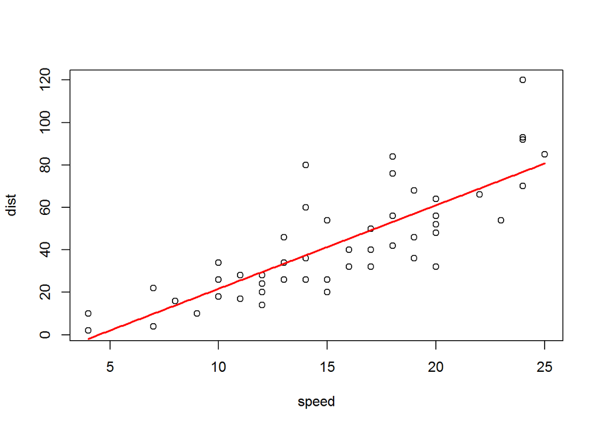

```r
  ls.func <- function(par, x, y) {
    b0 <- par[1]
    b1 <- par[2]
    err <- y - b1*x - b0
    sse <- sum(err^2)
  }

  ls.func.result <- optim(
    c(-17, 4),  # Initial parameter estimates
    ls.func,  # Fitting function
    method = "BFGS",  # Optimisation method
    x = cars$speed, y = cars$dist  # Function arguments
  )

  plot(cars)
  ls.func.Y <- ls.func.result$par[2]*u + ls.func.result$par[1]
  lines(u, ls.func.Y, lwd = 2, col = "red")
```

The predictions made with this set of functions match the results from lm() to four significant figures. This seems to be close enough when we look at the similarity between the plots.

The trick is to apply this to splines

### Applying linear models to splines

Splines are represented by an additive linear model, where each component of the spline does not interact with one another.

To determine the number of parameters for optimisation, the degree of the spline and the number of knots must be considered. These are added together to determine the number of components there are to the linear model

- 1 degree + 0 knots = 1 component = 2 parameters
- 2 degree + 2 knots = 4 components = 5 parameters

The basis matrix for a spline is used when fitting a model, therefore we use each part of the matrix as an independent variable to determine our dependent variable.

The spline we will work with will be a 2 degree spline with 2 knots. This is represented by the following equation:
$$y = B_1x_{*,1} + B_2*x_{*,2} + B_3*x_{*,3} + B_4*x_{*,4} + B_0$$
This is then made into a function. A more flexible function is mentioned later.

```r
  ls.spline2d2k.func <- function(par, x, y) {
    b0 <- par[1]
    b1 <- par[2]
    b2 <- par[3]
    b3 <- par[4]
    b4 <- par[5]
    err <- y - b1*x[,1] - b2*x[,2] - b3*x[,3] - b4*x[,4] - b0
    sse <- sum(err^2)
  }

  ls.spline2d2k.res <- optim(
    c(6, 8, 45, 49, 95),
    ls.spline2d2k.func,
    method = "BFGS",
    x = bs(cars$speed, knots = c(K), degree = 2), y = cars$dist
  )
```

To predict using a linear model of a spline, the new x value must be a matrix that represents the basis spline.

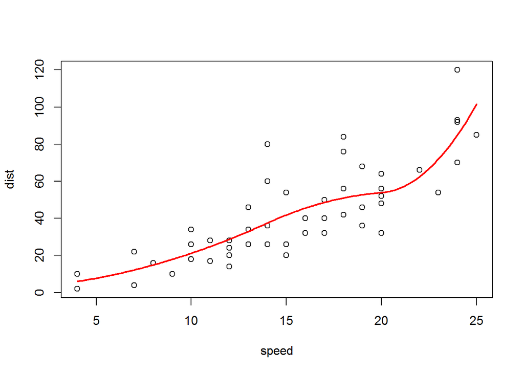

```r
  plot(cars)
  ls.spline.u <- bs(u, knots = c(K), degree = 2)
  ls.spline.Y <- ls.spline2d2k.res$par[2]*ls.spline.u[,1] +
    ls.spline2d2k.res$par[3]*ls.spline.u[,2] +
    ls.spline2d2k.res$par[4]*ls.spline.u[,3] +
    ls.spline2d2k.res$par[5]*ls.spline.u[,4] + ls.spline2d2k.res$par[1]
  lines(u, ls.spline.Y, lwd = 2, col = "red")
```

We can make a much more flexible function however…

```r
  flex.u <- bs(u, knots = c(K), degree = 2)
  flex.optres <- list(
    par = c(
      ls.spline2d2k.res$par[2],
      ls.spline2d2k.res$par[3],
      ls.spline2d2k.res$par[4],
      ls.spline2d2k.res$par[5],
      ls.spline2d2k.res$par[1]
    )
  )
  flex.optres.l <- length(flex.optres$par)
  flex.x <- bs(cars$speed, knots = c(K), degree = 2)

# For fitting
  flex.err <- cars$dist
  for (j in 1:flex.optres.l) {
    if (j != flex.optres.l) {
      flex.err <- flex.err - flex.optres$par[j]*flex.x[,j]
    } else {
      flex.err <- flex.err - flex.optres$par[j]
    }
  }
  flex.sse <- sum(flex.err^2)
  flex.sse != ls.spline2d2k.res$value
```

```
## [1] FALSE
```

```r
  lm.spline <- function(par, x, y) {
    err <- y
    for (i in 1:length(par)) {
      if (i != length(par)) {
        err <- err - par[i]*x[,i]
      } else if (i == length(par)) {
        err <- err - par[i]
      }
    }
    return(sum(err^2))
  }

  test <- optim(
    c(8, 45, 49, 95, 6),  # Initial parameter estimates
    lm.spline,  # Fitting function
    method = "BFGS",
    x = bs(cars$speed, knots = c(K), degree = 2), y = cars$dist # Function arg.
  )
  test$value != ls.spline2d2k.res$value
```

```
## [1] FALSE
```

```r
# For predicting
  flex.optres.l <- length(flex.optres$par)
  flex.Y <- double(length(u))
  for (j in 1:flex.optres.l) {
    if (j != flex.optres.l) {
      flex.Y <- flex.Y + flex.optres$par[j]*flex.u[,j]
    } else {
      flex.Y <- flex.Y + flex.optres$par[j]
    }
  }
  any(flex.Y != ls.spline.Y)
```

```
## [1] FALSE
```

The three logical statements from the above script are to test whether there are any mistakes in how the code is implemented. As they are all false, we now have an accurate flexible set of functions to fit splines with.

For the following function:

- x = the new x values for which you want to predict y
- par = the coefficients of the spline you have fitted
- K = the knots used to fit the spline
- n = the degree used to fit the spline

```r
  predict.spline <- function(x, par, K, n) {
    bs.mat <- bs(x, knots = c(K), degree = n)
    out <- double(length(x))
    for (i in 1:length(par)) {
      if (i != length(par)) {
        out <- out + par[i]*bs.mat[,i]
      } else if (i == length(par)) {
        out <- out + par[i]
      }
    }
    return(out)
  }
```

### Applying linear models using maximum likelihood

Lastly lets adjust these functions so that they can be used with maximum likelihood estimation and see how much of a difference it makes for the spline. The function that is given to optim() needs to also optimise sigma so we add another parameter.

[figure not shown]

```r
  mle.spline <- function(par, x, y) {
    err <- y
    for (i in 1:length(par)) {
      if (i < length(par) - 1) {
        err <- err - par[i]*x[,i]
      } else if (i == length(par) - 1) {
        err <- err - par[i]
      }
    }
    loglik <- dnorm(err, 0, tail(par, 1), log = T)
    return(-1*sum(loglik))
  }

  mle.test.res <- optim(
    c(8, 45, 49, 95, 6),  # Initial parameter estimates
    mle.spline,  # Fitting function
    method = "BFGS",
    x = bs(cars$speed, knots = c(K), degree = 2), y = cars$dist # Function arg.
  )

  mle.test.Y <- predict.spline(u, mle.test.res$par[-length(mle.test.res$par)], K, 2)
  plot(cars)
  lines(u, mle.test.Y, lwd = 2, col = "red")
```

This isn’t perfect though if you don’t have good initial estimates

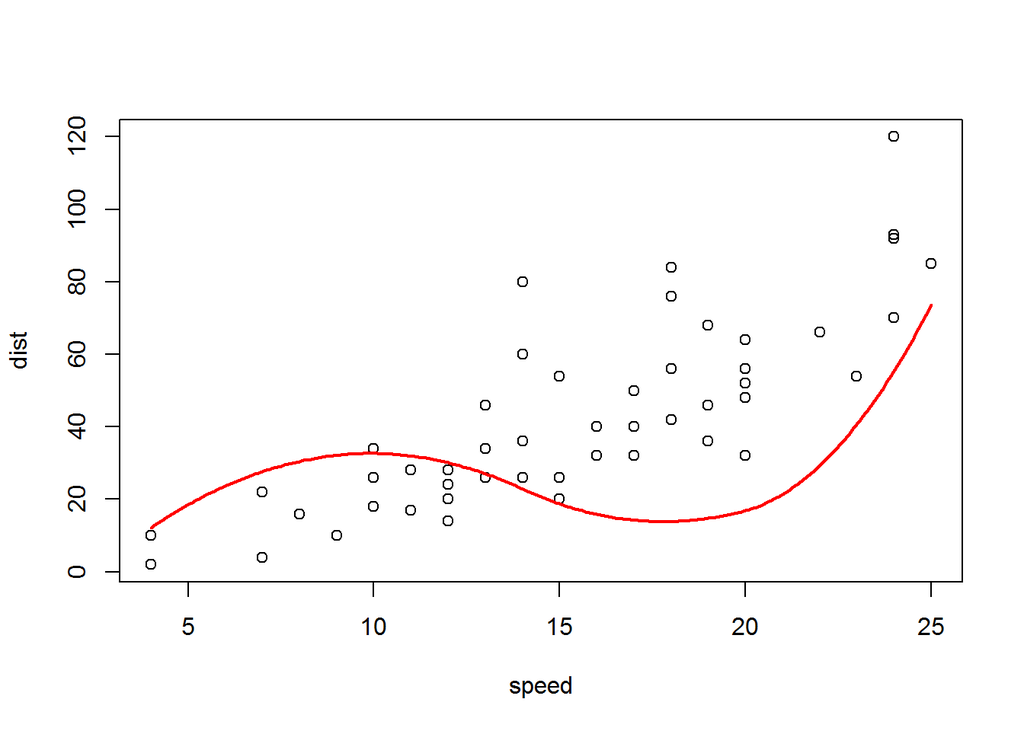

```r
  mle.test.res2 <- optim(
    c(50, 2, 8, 60, 35, 1),  # Initial parameter estimates
    mle.spline,  # Fitting function
    method = "BFGS",
    x = bs(cars$speed, knots = c(K), degree = 2), y = cars$dist # Function arg.
  )

  mle.test.Y <- predict.spline(u, mle.test.res2$par[-length(mle.test.res2$par)], K, 2)
  plot(cars)
  lines(u, mle.test.Y, lwd = 2, col = "red")
```

Ideally you would use lm() to get initial estimates for your spline.

### Pharmacokinetic example

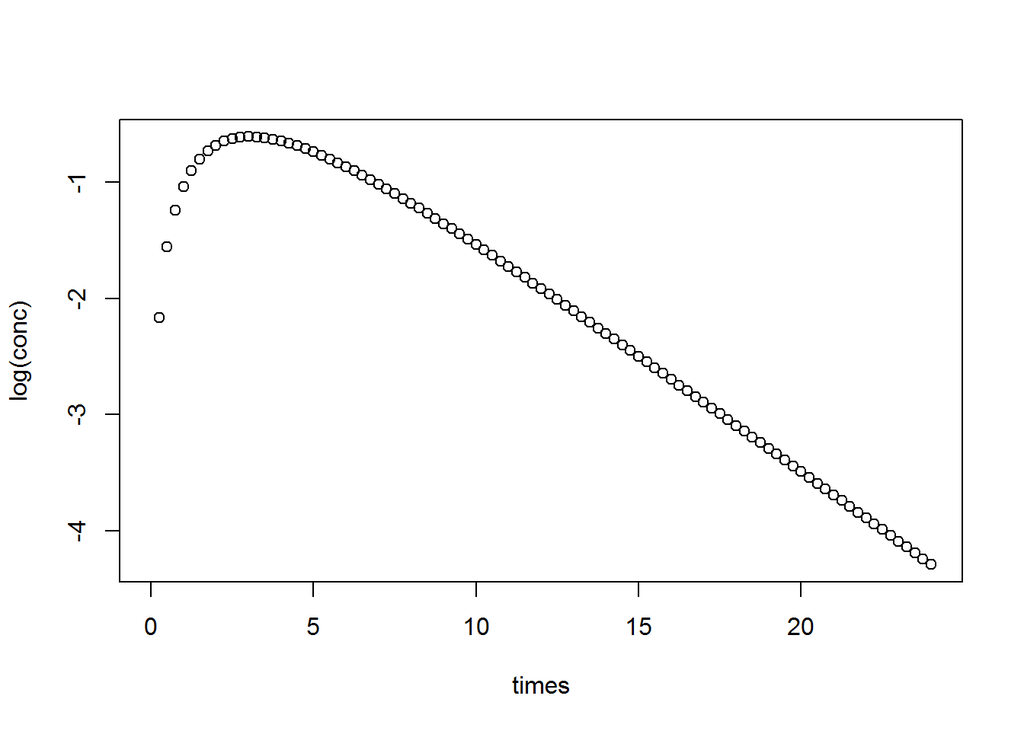

```r
  times <- seq(from = 0, to = 24, by = 0.25)    # Time sequence for simulating concentrations

# Simulate dataset
  K <- c(5, 10)  # knots
  CL <- 10  # Clearance, 10 L/h
  V <- 50   # Volume of concribution, 50 L
  KA <- 0.5 # Absorption rate constant, h^-1
  ERR <- 1 + rnorm(n = length(times), mean = 0, sd = 0.3)
  dose <- 50    # mg
  sample.times <- c(0, 0.25, 0.5, 1, 2, 4, 8, 12, 24)  # Sampling times
  conc <- dose*KA/(V*(KA-(CL/V)))*(exp(-CL/V*times)-exp(-KA*times))
  plot(times, log(conc))
```

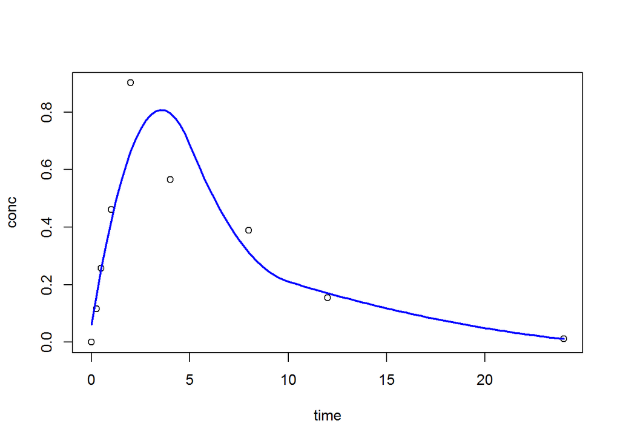

```r
  sample.conc <- (conc*ERR)[times %in% sample.times]
  onecomp <- data.frame(time = sample.times, conc = sample.conc)

# Find our initial estimates using QR decomposition via lm()
  pk.modlm <- lm(conc ~ bs(time, knots = c(K), degree = 2), data = onecomp)
  init.par <- unname(pk.modlm$coefficients[c(2:5, 1)])

# Supress warnings due to NaN being produced by estimating sigma of < 0
  suppressWarnings(
    pk.optres <- optim(
      c(init.par, 1),  # Initial parameter estimates
      mle.spline,  # Fitting function
      method = "BFGS",
      x = bs(onecomp$time, knots = c(K), degree = 2), y = onecomp$conc # Function arg.
    )
  )

  u <- times
  B <- data.frame(time = u)
  pk.lm.Y <- predict(pk.modlm, newdata = B)
  pk.mle.Y <- predict.spline(u, pk.optres$par[-length(pk.optres$par)], K, 2)
  plot(onecomp)
  lines(u, pk.lm.Y, lwd = 2, col = "red")
  lines(u, pk.mle.Y, lwd = 2, col = "blue")
```

The two lines aren’t visibly different when plotted This phenomemon is the same when observing drugs with two-compartment kinetics So while using least squares here shows little difference, if you are using maximum likelihood as a method later in your script, its best to be consistent with your methods.

Also maximum likelihood is generally better anyway, even if it isn’t for this case.